## Show the sample mean and compare it to the theoretical mean of the distribution

First, let’s set our lambda value and calculate the theoretical mean, given by 1/lambda.

```r
# Lambda
l = 0.2

# Theoretical mean
1/l
```

```
## [1] 5
```

Next, let’s generate a single sample of 40 exponentials, and take a look at the mean that is generated.

```r
# Set the random seed for reproducible results
set.seed(12345)

# Set N
n = 40

# Take the mean of the generated sample
mean(rexp(n, l))
```

```
## [1] 5.553693
```

We see that the mean is larger than the theoretical mean.

However, per the Law of Large Numbers, larger samples will lead to a closer approximation of theoretical parameters. Thus, if we use a larger n, we more closely approximate the theoretical mean.

```r
# Set the random seed for reproducible results
set.seed(12345)

# List of sample sizes to simulate
ns <- c(40, 400, 4000, 40000, 400000)

means <- NULL
# For each sample size in the list, generate a
# distribution, take the mean, and put it into a
# collection of means
for(i in 1:length(ns)){
  means <- rbind(means, round(mean(rexp(ns[i], l)), 2))
}
# Print the means
means
```

```
##      [,1]
## [1,] 5.55
## [2,] 4.68
## [3,] 5.01
## [4,] 4.97
## [5,] 5.00
```

For example, we see here that once we get into the 1000s, the sample mean is much closer to the theoretical mean.

We can also look at the mean of a distribution of 1000 means – each representing a sample of 40 exponentials.

```r
# Set the random seed for reproducible results
set.seed(12345)

means <- NULL
# Generate 1000 distributions of 40 exponentials,
# taking the mean of each one and putting it into
# a collection of means
for (i in 1:1000){
  means = c(means, mean(rexp(n, l)))
}
# Mean of means
mean(means)
```

```
## [1] 4.971972
```

Here too we see that it is closer than a single sample, per the LLN.

## Show how variable the sample is (via variance) and compare it to the theoretical variance of the distribution

```r
l = 0.2

1/l
```

```
## [1] 5
```

Next, let’s generate a single sample of 40 exponentials, and take a look at the sd that is generated.

```r
# Set the random seed for reproducible results
set.seed(12345)

# Set N
n = 40

# Take the sd of the generated sample
sd(rexp(n, l))
```

```
## [1] 6.475255
```

We see that it is larger than the theoretical value. This is to be expected, because smaller samples are noisier.

Next let’s look at the SD with more exponentials. Per the Law of Large Numbers, our variance parameter converges on the theoretical value.

```r
# Set the random seed for reproducible results
set.seed(12345)

# List of sample sizes to simulate
ns <- c(40, 400, 4000, 40000, 400000)

sds <- NULL
# For each sample size in the list, generate a
# distribution, take the sd, and put it into a
# collection of sds
for(i in 1:length(ns)){
  sds <- rbind(sds, round(sd(rexp(ns[i], l)), 2))
}
# Print the sds
sds
```

```
##      [,1]
## [1,] 6.48
## [2,] 4.71
## [3,] 5.01
## [4,] 4.95
## [5,] 5.00
```

We can also look at the SD of a distribution of 1000 distribution averages – each representing a sample of 40 exponentials.

```r
# Set the random seed for reproducible results
set.seed(12345)

means = NULL
# Generate 1000 distributions of 40 exponentials,
# taking the mean of each one and putting it into
# a collection of means
for (i in 1:1000){
  means = c(means, mean(rexp(n, l)))
}
# Mean of the distribution of sds
sd(means)
```

```
## [1] 0.7716456
```

```r
5/40
```

```
## [1] 0.125
```

## Show that the distribution is approximately normal

Next we can look at the distribution of averages of 40 exponentials.

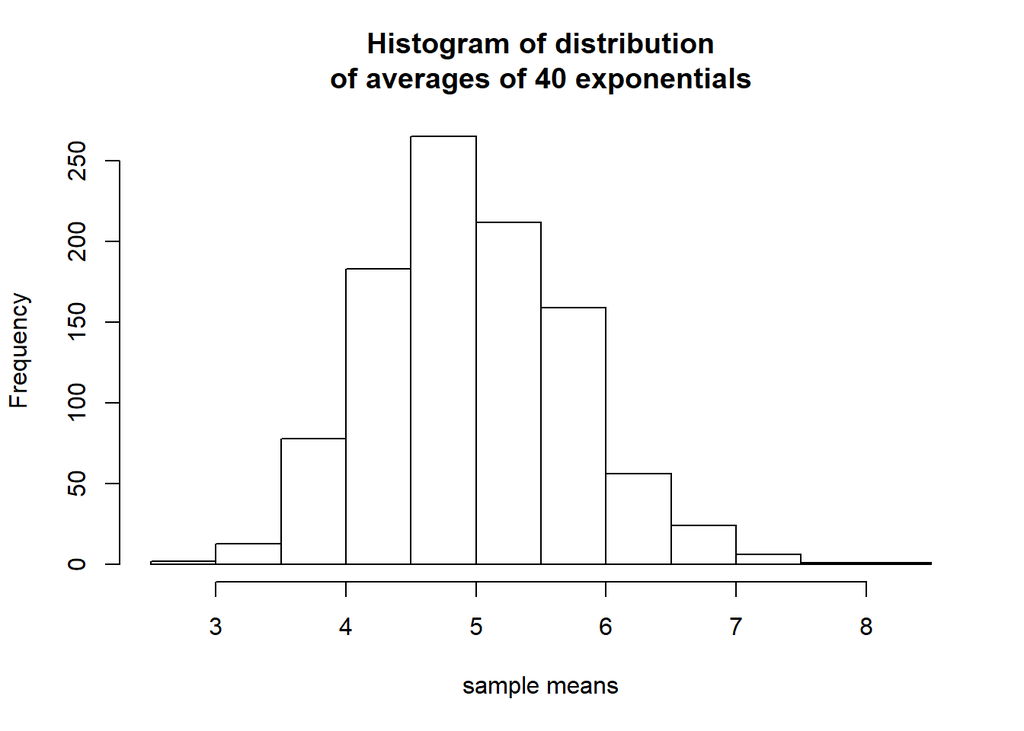

```r
# Set the random seed for reproducible results
set.seed(12345)

means <- NULL
# Generate 1000 distributions of 40 exponentials,
# taking the mean of each one and putting it into
# a collection of means
for (i in 1:1000){
  means <- c(means, mean(rexp(n, l)))
}
# Histogram
hist(means,
     main = "Histogram of distribution\nof averages of 40 exponentials",
     xlab = "sample means")
```

We see that it is approximately normal. We know this because of the symmetrical, bell-curved shape.

For example, the following is a histogram of a sample generated using random numbers from a normal distribution

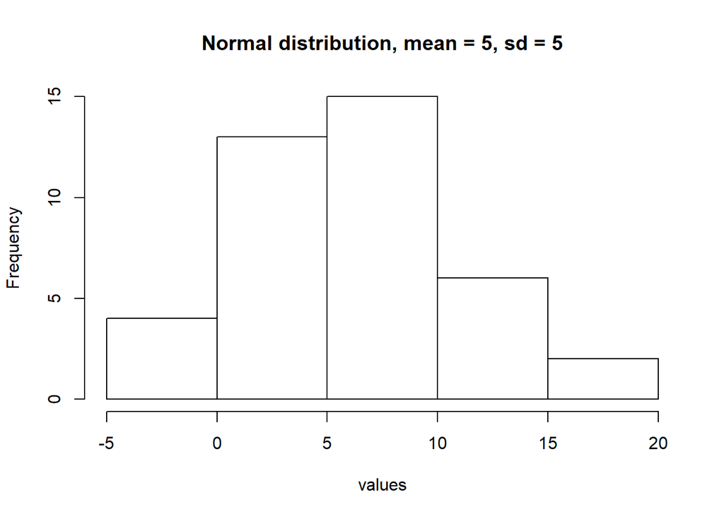

```r
# Set the random seed for reproducible results
set.seed(12345)

hist(rnorm(n, mean = 5, sd = 5),
     main = "Normal distribution, mean = 5, sd = 5",
     xlab = "values")
```

If we compare this to a large collection of exponentials we see that it is non-normal. We know it is non-normal because it does not have a symmetrical, bell-curved shape. It is skewed towards 0.

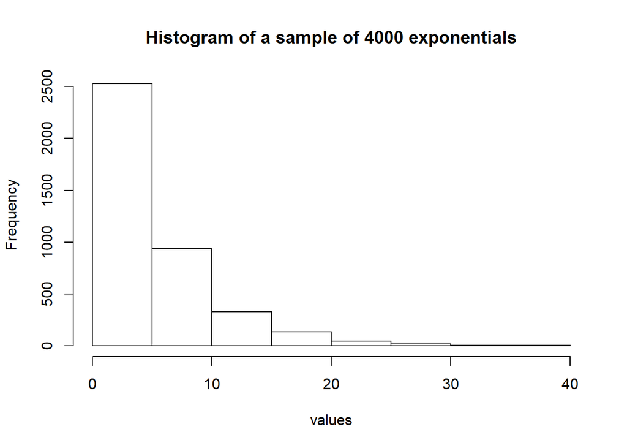

```r
# Set the random seed for reproducible results
set.seed(12345)

# Set N to something large
n = 4000

# Histogram of the generated sample
hist(rexp(n, l),
     main = "Histogram of a sample of 4000 exponentials",
     xlab = "values")
```